# Biostatistics Methods 1 Final Project

Manqi Cai, Yixi Xu, Peng-Lin Lin, Kaitlin Maciejewski

12/9/2017

The Data Analytics group from Good Health Corporation are interested in improving the overall hospital management and minimizing the cost/resources associated with patients’ care. One of the most important outcomes that has a direct effect on these aspects is patient’s length of stay (LoS) in the hospital. Thus, they would like to know which variables are associated with LoS, and ultimately build a predictive model to be used for future visits. The group has contacted you to study this problem and make a recommendation.

```r
ghproject <- read_excel("GHProject_Dataset.xlsx") %>%
  clean_names()

#summary of continuous variable

attach(ghproject)

sd(loshours, na.rm = T)
```

```
## [1] 142.3524
```

```r
sd(losdays2, na.rm = T)
```

```
## [1] 5.931351
```

```r
sd(ageyear, na.rm = T)
```

```
## [1] 18.66037
```

```r
sd(bmi, na.rm = T)
```

```
## [1] 7.961884
```

```r
sd(bpdiastolic, na.rm = T)
```

```
## [1] 9.828815
```

```r
sd(o2sat, na.rm = T)
```

```
## [1] 4.864867
```

```r
sd(temperature, na.rm = T)
```

```
## [1] 0.9084958
```

```r
sd(heartrate, na.rm = T)
```

```
## [1] 12.97154
```

```r
sd(respirationrate, na.rm = T)
```

```
## [1] 2.6465
```

```r
sd(bpsystolic, na.rm = T)
```

```
## [1] 16.77863
```

```r
#summary of categorical data
ghproject %>%
  group_by(mews) %>%
  summarize(n())
```

```
## # A tibble: 15 x 2
##     mews `n()`
##    <dbl> <int>
##  1     0    39
##  2     1   618
##  3     2   730
##  4     3   801
##  5     4   711
##  6     5   328
##  7     6   151
##  8     7    87
##  9     8    26
## 10     9    14
## 11    10     5
## 12    11     4
## 13    12     1
## 14    14     1
## 15    NA   166
```

```r
ghproject %>%
  group_by(cindex) %>%
  summarize(n())
```

```
## # A tibble: 5 x 2
##   cindex `n()`
##    <dbl> <int>
## 1      0  1207
## 2      1   636
## 3      2   722
## 4      3   435
## 5      5   682
```

```r
ghproject %>%
  group_by(evisit) %>%
  summarize(n())
```

```
## # A tibble: 5 x 2
##   evisit `n()`
##    <dbl> <int>
## 1      0  1134
## 2      1   752
## 3      2   521
## 4      3   329
## 5      4   946
```

```r
ghproject %>%
  group_by(icu_flag) %>%
  summarize(n())
```

```
## # A tibble: 2 x 2
##   icu_flag `n()`
##      <dbl> <int>
## 1        0  3618
## 2        1    64
```

```r
ghproject %>%
  group_by(gender) %>%
  summarize(n())
```

```
## # A tibble: 2 x 2
##   gender `n()`
##    <chr> <int>
## 1 Female  1981
## 2   Male  1701
```

```r
ghproject %>%
  group_by(race) %>%
  summarize(n())
```

```
## # A tibble: 6 x 2
##                   race `n()`
##                  <chr> <int>
## 1   African Amer/Black   788
## 2                Asian   253
## 3  Native Amer/Alaskan    22
## 4 Natv Hawaii/Pacf Isl     4
## 5    Other/Multiracial   526
## 6                White  2089
```

```r
ghproject %>%
  group_by(religion) %>%
  summarize(n())
```

```
## # A tibble: 11 x 2
##              religion `n()`
##                 <chr> <int>
##  1          Angelican     1
##  2           Catholic  1678
##  3          Christian   909
##  4             Hebrew     1
##  5              Hindu   127
##  6              Islam   112
##  7             Jewish   527
##  8             Mormon     2
##  9     No Affiliation   177
## 10 Non Denominational     1
## 11              Other   147
```

```r
ghproject %>%
  group_by(maritalstatus) %>%
  summarize(n())
```

```
## # A tibble: 7 x 2
##   maritalstatus `n()`
##           <chr> <int>
## 1   Civil Union     1
## 2      Divorced   241
## 3       Married  1637
## 4     Separated    52
## 5        Single   967
## 6       Widowed   704
## 7          <NA>    80
```

```r
ghproject %>%
  group_by(facilityname) %>%
  summarize(n())
```

```
## # A tibble: 8 x 2
##                  facilityname `n()`
##                         <chr> <int>
## 1         Lenox Hill Hospital     5
## 2            LIJ Forest Hills   568
## 3           LIJ Valley Stream   331
## 4 Long Island Jewish Hospital   828
## 5                        NSUH  1011
## 6          Plainview Hospital   328
## 7          Southside Hospital   528
## 8            Syosset Hospital    83
```

```r
ghproject %>%
  group_by(insurancetype) %>%
  summarize(n())
```

```
## # A tibble: 4 x 2
##   insurancetype `n()`
##           <chr> <int>
## 1      Medicaid   170
## 2      Medicare  1457
## 3       Private  2021
## 4          <NA>    34
```

```r
#summary of PatientID and VisitID
ghproject %>%
  distinct(patientid) %>%
  count()
```

```
## # A tibble: 1 x 1
##       n
##   <int>
## 1  3612
```

```r
ghproject %>%
  distinct(visitid) %>%
  count()
```

```
## # A tibble: 1 x 1
##       n
##   <int>
## 1  3682
```

There are 3682 records from 3612 patients

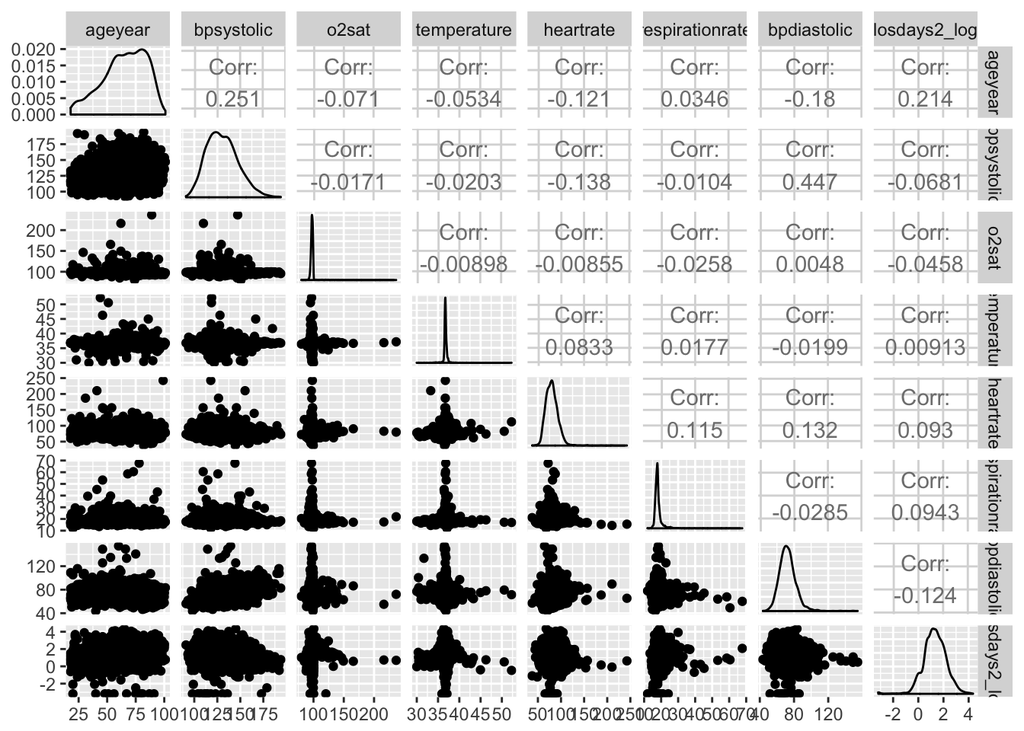

```r
# correlation matrix for numeric variables, saturated

ggpairs(ghproject_tidy, columns = c("ageyear", "bpsystolic","o2sat","temperature", "heartrate","respirationrate", "bpdiastolic","losdays2_log"))
```

# SAS output:

## Forward

### significant variables:

ageyear, evisit, bpsystolic, cindex, heartrate, is30dayreadmit, respirationrate

AdjR2: 0.1169

AIC: 1743.8

## Backward

AdjR2: 0.1169

AIC: 1743.8

## Stepwise

### significant variables:

ageyear, evisit, bpsystolic, cindex, heartrate, is30dayreadmit, respirationrate

AdjR2: 0.1169

AIC: 1743.8

All models agree

```r
reg <- lm(losdays2_log ~ is30dayreadmit + ageyear +  cindex  + insurancetype + bpsystolic + o2sat + heartrate +  respirationrate, ghproject_tidy)

summary(reg)
```

```
##
## Call:
## lm(formula = losdays2_log ~ is30dayreadmit + ageyear + cindex +
##     insurancetype + bpsystolic + o2sat + heartrate + respirationrate,
##     data = ghproject_tidy)
##
## Residuals:
##     Min      1Q  Median      3Q     Max
## -5.0899 -0.4820  0.0048  0.5188  2.9834
##
## Coefficients:
##                   Estimate Std. Error t value Pr(>|t|)
## (Intercept)      0.7674030  0.3663017   2.095 0.036264 *
## is30dayreadmit   0.2597481  0.0468562   5.544 3.25e-08 ***
## ageyear          0.0092775  0.0009619   9.645  < 2e-16 ***
## cindex           0.1364620  0.0221881   6.150 8.88e-10 ***
## insurancetype    0.1130282  0.0284840   3.968 7.43e-05 ***
## bpsystolic      -0.0057149  0.0010042  -5.691 1.40e-08 ***
## o2sat           -0.0044032  0.0030484  -1.444 0.148733
## heartrate        0.0058341  0.0012381   4.712 2.58e-06 ***
## respirationrate  0.0195876  0.0059103   3.314 0.000931 ***
## ---
## Signif. codes:  0 '***' 0.001 '**' 0.01 '*' 0.05 '.' 0.1 ' ' 1
##
## Residual standard error: 0.8388 on 2700 degrees of freedom
## Multiple R-squared:  0.1109, Adjusted R-squared:  0.1083
## F-statistic: 42.09 on 8 and 2700 DF,  p-value: < 2.2e-16
```

```r
confint(reg)
```

```
##                        2.5 %       97.5 %
## (Intercept)      0.049142821  1.485663164
## is30dayreadmit   0.167870341  0.351625827
## ageyear          0.007391456  0.011163552
## cindex           0.092954613  0.179969435
## insurancetype    0.057175656  0.168880799
## bpsystolic      -0.007683974 -0.003745901
## o2sat           -0.010380604  0.001574214
## heartrate        0.003406370  0.008261864
## respirationrate  0.007998328  0.031176774
```

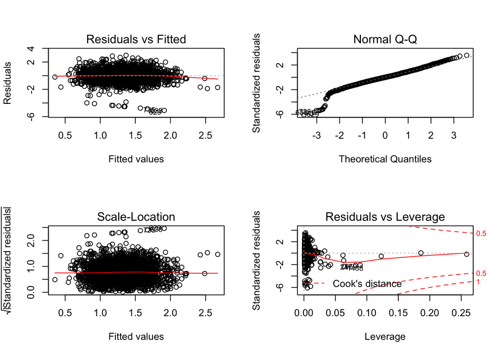

```r
par(mfrow=c(2,2))
plot(reg)
```

```r
#identifies which observations to remove
stu_res <- rstandard(reg)
outlier <- stu_res[abs(stu_res) > 2.5]

is.outlier = function(value, vector){
  value %in% outlier
}

data_no_outliers = ghproject_tidy %>%
  mutate(outlier = is.outlier(stu_res, outlier))%>%
  filter(outlier == FALSE)

data_no_outliers %>%
  group_by(gender) %>%
  count()
```

```
## # A tibble: 2 x 2
## # Groups:   gender [2]
##   gender     n
##    <int> <int>
## 1      0  1448
## 2      1  1218
```

```r
#refit model with no outliers
reg_no_outliers <- lm(losdays2_log ~ is30dayreadmit + ageyear +  cindex  + insurancetype + bpsystolic + o2sat + heartrate +  respirationrate, data_no_outliers)

summary(reg_no_outliers)
```

```
##
## Call:
## lm(formula = losdays2_log ~ is30dayreadmit + ageyear + cindex +
##     insurancetype + bpsystolic + o2sat + heartrate + respirationrate,
##     data = data_no_outliers)
##
## Residuals:
##      Min       1Q   Median       3Q      Max
## -2.09710 -0.48366 -0.00958  0.48504  2.12177
##
## Coefficients:
##                   Estimate Std. Error t value Pr(>|t|)
## (Intercept)      0.7095302  0.3274788   2.167 0.030351 *
## is30dayreadmit   0.2674520  0.0419803   6.371 2.21e-10 ***
## ageyear          0.0096754  0.0008669  11.161  < 2e-16 ***
## cindex           0.1271358  0.0198810   6.395 1.89e-10 ***
## insurancetype    0.0961222  0.0256676   3.745 0.000184 ***
## bpsystolic      -0.0059429  0.0009011  -6.595 5.10e-11 ***
## o2sat           -0.0032183  0.0027216  -1.182 0.237121
## heartrate        0.0053301  0.0011077   4.812 1.58e-06 ***
## respirationrate  0.0212500  0.0053352   3.983 6.99e-05 ***
## ---
## Signif. codes:  0 '***' 0.001 '**' 0.01 '*' 0.05 '.' 0.1 ' ' 1
##
## Residual standard error: 0.7458 on 2657 degrees of freedom
## Multiple R-squared:  0.1341, Adjusted R-squared:  0.1315
## F-statistic: 51.42 on 8 and 2657 DF,  p-value: < 2.2e-16
```

```r
confint(reg_no_outliers)
```

```
##                        2.5 %       97.5 %
## (Intercept)      0.067391071  1.351669387
## is30dayreadmit   0.185134664  0.349769276
## ageyear          0.007975497  0.011375263
## cindex           0.088152003  0.166119534
## insurancetype    0.045791699  0.146452626
## bpsystolic      -0.007709847 -0.004176027
## o2sat           -0.008555028  0.002118464
## heartrate        0.003158059  0.007502067
## respirationrate  0.010788480  0.031711433
```

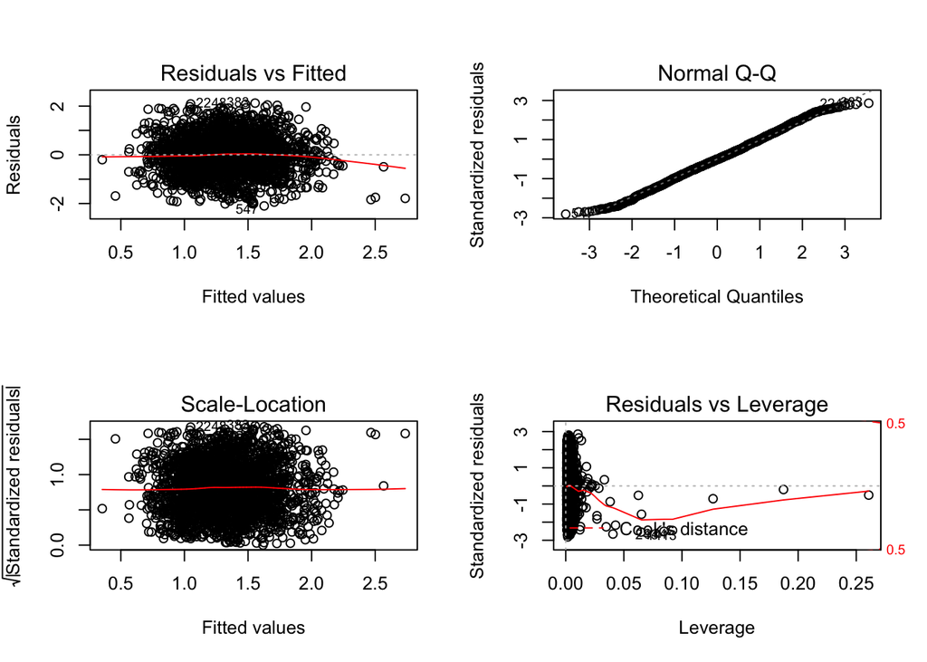

```r
par(mfrow=c(2,2))
plot(reg_no_outliers)
```

```r
## remove o2sat

reg_no_outliers_1 <- lm(losdays2_log ~ is30dayreadmit + ageyear +  cindex  + insurancetype + bpsystolic + heartrate +  respirationrate, data_no_outliers)

summary(reg_no_outliers_1)
```

```
##
## Call:
## lm(formula = losdays2_log ~ is30dayreadmit + ageyear + cindex +
##     insurancetype + bpsystolic + heartrate + respirationrate,
##     data = data_no_outliers)
##
## Residuals:
##      Min       1Q   Median       3Q      Max
## -2.09763 -0.48678 -0.01201  0.49003  2.12255
##
## Coefficients:
##                   Estimate Std. Error t value Pr(>|t|)
## (Intercept)      0.3862749  0.1803208   2.142 0.032272 *
## is30dayreadmit   0.2665833  0.0419770   6.351 2.51e-10 ***
## ageyear          0.0097364  0.0008654  11.250  < 2e-16 ***
## cindex           0.1276104  0.0198784   6.420 1.61e-10 ***
## insurancetype    0.0964752  0.0256678   3.759 0.000175 ***
## bpsystolic      -0.0059440  0.0009012  -6.596 5.08e-11 ***
## heartrate        0.0053471  0.0011077   4.827 1.46e-06 ***
## respirationrate  0.0213752  0.0053345   4.007 6.32e-05 ***
## ---
## Signif. codes:  0 '***' 0.001 '**' 0.01 '*' 0.05 '.' 0.1 ' ' 1
##
## Residual standard error: 0.7459 on 2658 degrees of freedom
## Multiple R-squared:  0.1336, Adjusted R-squared:  0.1313
## F-statistic: 58.55 on 7 and 2658 DF,  p-value: < 2.2e-16
```

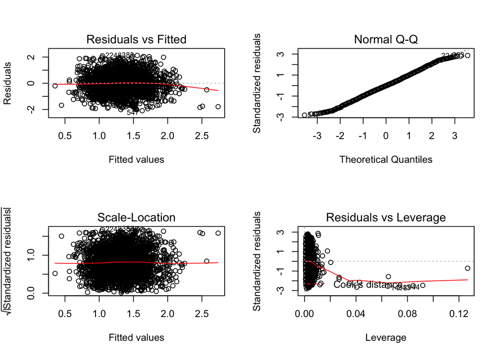

```r
par(mfrow=c(2,2))
plot(reg_no_outliers_1)
```

```r
set.seed(1)
##boostrap method
# load the library
library(caret)
# define training control
train_control <- trainControl(method="boot", number=1000)
# fix the parameters of the algorithm
grid <- expand.grid(.fL=c(0), .usekernel=c(FALSE))
# train the model
model <- train(losdays2_log ~ is30dayreadmit + ageyear + cindex + evisit + gender + maritalstatus + insurancetype + bpsystolic + heartrate +  respirationrate + bpdiastolic, data=data_no_outliers, trControl=train_control, method='lm')
# summarize results
print(model)
```

```
## Linear Regression
##
## 2666 samples
##   11 predictor
##
## No pre-processing
## Resampling: Bootstrapped (1000 reps)
## Summary of sample sizes: 2666, 2666, 2666, 2666, 2666, 2666, ...
## Resampling results:
##
##   RMSE       Rsquared   MAE
##   0.7431896  0.1406487  0.5889454
##
## Tuning parameter 'intercept' was held constant at a value of TRUE
```

```r
set.seed(1)
##cross-validation method
# load the library
library(caret)
# define training control
train_control <- trainControl(method="cv", number=10)
# fix the parameters of the algorithm
grid <- expand.grid(.fL=c(0), .usekernel=c(FALSE))
# train the model
model <- train(losdays2_log ~ + is30dayreadmit + ageyear + cindex + evisit + gender + maritalstatus + insurancetype + bpsystolic + heartrate +  respirationrate + bpdiastolic, data=data_no_outliers, trControl=train_control, method='lm')
# summarize results
print(model)
```

```
## Linear Regression
##
## 2666 samples
##   11 predictor
##
## No pre-processing
## Resampling: Cross-Validated (10 fold)
## Summary of sample sizes: 2400, 2399, 2399, 2400, 2399, 2398, ...
## Resampling results:
##
##   RMSE       Rsquared   MAE
##   0.7399242  0.1464167  0.5866044
##
## Tuning parameter 'intercept' was held constant at a value of TRUE
```

[interactive table not shown]